# Practical Machine Learning Week 4

François DELATTRE

26 décembre 2017

## Data reading

The training set is dowloaded from https://d396qusza40orc.cloudfront.net/predmachlearn/pml-training.csv The testing set is downloaded from https://d396qusza40orc.cloudfront.net/predmachlearn/pml-testing.csv

Both datasets are read using the readr package, skipping columns that are not measures. We also force some columns to be treated as double type.

```r
library(readr)
train <- read_csv("https://d396qusza40orc.cloudfront.net/predmachlearn/pml-training.csv",
                  na = c('NA', '#DIV/0!', ''),  # there are different forms of NAs in the file
                  col_types = cols(
                    X1 = col_skip(),
                    kurtosis_yaw_belt = col_double(),
                    skewness_yaw_belt = col_double(),
                    kurtosis_yaw_dumbbell = col_double(),
                    skewness_yaw_dumbbell = col_double(),
                    magnet_dumbbell_z = col_double(),
                    magnet_forearm_y = col_double(),
                    magnet_forearm_z = col_double(),
                    cvtd_timestamp = col_skip(),
                    new_window = col_skip(),
                    num_window = col_skip(),
                    raw_timestamp_part_1 = col_skip(),
                    raw_timestamp_part_2 = col_skip(),
                    user_name = col_skip()))
test  <- read_csv("https://d396qusza40orc.cloudfront.net/predmachlearn/pml-testing.csv",
                  na = c('NA', '#DIV/0!', ''),
                  col_types = cols(
                    X1 = col_skip(),
                    magnet_dumbbell_z = col_double(),
                    magnet_forearm_y = col_double(),
                    magnet_forearm_z = col_double(),
                    cvtd_timestamp = col_skip(),
                    new_window = col_skip(),
                    num_window = col_skip(),
                    raw_timestamp_part_1 = col_skip(),
                    raw_timestamp_part_2 = col_skip(),
                    user_name = col_skip()))
```

## Data analysis

Let’s perform a quick analysis especially to better understand our dataset

### Missing values

```r
na_ratio <- apply(train, MARGIN = 2, FUN = function(col){length(which(is.na(col)))/nrow(train)})

little_missing <- names(na_ratio[na_ratio > 0 & na_ratio <.3])
lot_missing <- names(na_ratio[na_ratio > .3])
```

100 features have many missing values 53 features have no missing values at all

Let’s remove the features that have too many missing values

```r
train <- train[, !colnames(train)%in%lot_missing]
test  <- test[, !colnames(test)%in%lot_missing]
```

### Target distribution

The following code produces a plot showing the row counts within each target

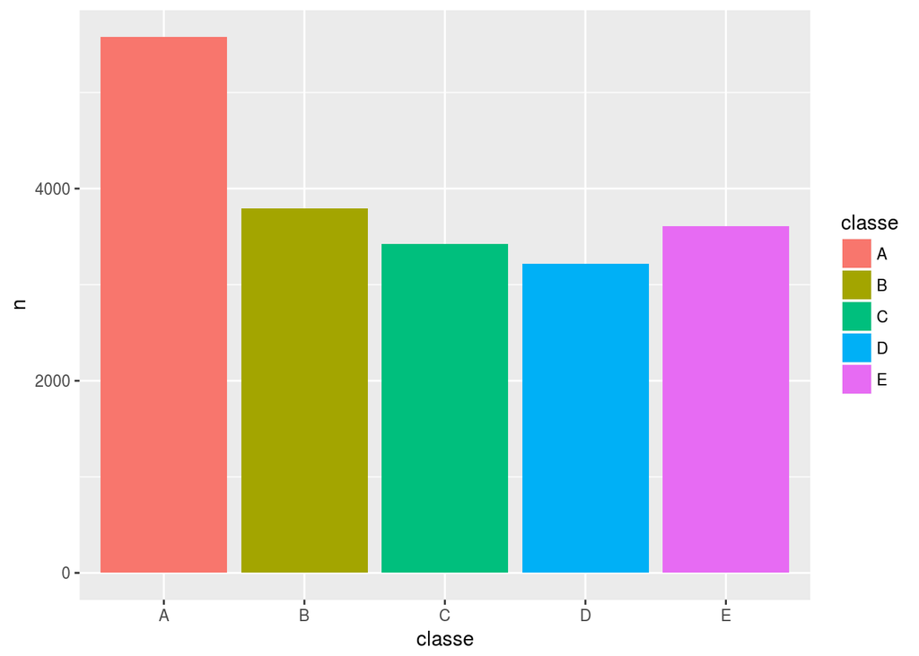

```r
library(ggplot2)
library(dplyr)
target_counts <- train %>%
  group_by(classe)%>%
  tally()

ggplot(target_counts)+
  geom_col(aes(classe, n, fill= classe))
```

## Modelling

We will use the caret package to model the classe variable.

### Splitting

We will split our training data into a train set and a test set. The train set will be used to train our model. The test set will used to estimate the error.

```r
library(caret)
trainIndex <- createDataPartition(train$classe, p = .8,
                                  list = FALSE,
                                  times = 1)

modTrain <- train[ trainIndex,]
modTest  <- train[-trainIndex,]
```

### Pre Processing

We wiil now apply some pre Processing techniques to our training dataset. (center / scale / remove almost constant features)

```r
preProcValues <- preProcess(modTrain, method = c("center", "scale", "nzv"))

trainTransformed <- predict(preProcValues, modTrain)
testTransformed <- predict(preProcValues, modTest)
```

### Modeling

We will model the classe variable using the caret package. A 3-fold cross validation is used to estimate the best parameters, using the Accuracy as the metric to optimise.

```r
fitControl <- trainControl(method = "cv",
                           number = 3)

set.seed(2802)
xgbFit <- train(classe ~ ., data = trainTransformed,
                 method = "xgbTree",
                 trControl = fitControl,
                 verbose=FALSE)
xgbFit
```

```
## eXtreme Gradient Boosting
##
## 15699 samples
##    52 predictors
##     5 classes: 'A', 'B', 'C', 'D', 'E'
##
## No pre-processing
## Resampling: Cross-Validated (3 fold)
## Summary of sample sizes: 10467, 10465, 10466
## Resampling results across tuning parameters:
##
##   eta  max_depth  colsample_bytree  subsample  nrounds  Accuracy
##   0.3  1          0.6               0.50        50      0.8021539
##   0.3  1          0.6               0.50       100      0.8602465
##   0.3  1          0.6               0.50       150      0.8876363
##   0.3  1          0.6               0.75        50      0.7975680
##   0.3  1          0.6               0.75       100      0.8568066
##   0.3  1          0.6               0.75       150      0.8866169
##   0.3  1          0.6               1.00        50      0.7955295
##   0.3  1          0.6               1.00       100      0.8528578
##   0.3  1          0.6               1.00       150      0.8838146
##   0.3  1          0.8               0.50        50      0.8017712
##   0.3  1          0.8               0.50       100      0.8606919
##   0.3  1          0.8               0.50       150      0.8890374
##   0.3  1          0.8               0.75        50      0.7986508
##   0.3  1          0.8               0.75       100      0.8570613
##   0.3  1          0.8               0.75       150      0.8864900
##   0.3  1          0.8               1.00        50      0.7958484
##   0.3  1          0.8               1.00       100      0.8548324
##   0.3  1          0.8               1.00       150      0.8845789
##   0.3  2          0.6               0.50        50      0.9135616
##   0.3  2          0.6               0.50       100      0.9548379
##   0.3  2          0.6               0.50       150      0.9716544
##   0.3  2          0.6               0.75        50      0.9112049
##   0.3  2          0.6               0.75       100      0.9542649
##   0.3  2          0.6               0.75       150      0.9708905
##   0.3  2          0.6               1.00        50      0.9092935
##   0.3  2          0.6               1.00       100      0.9515893
##   0.3  2          0.6               1.00       150      0.9673230
##   0.3  2          0.8               0.50        50      0.9156635
```

[output cut: 182 more lines]

```
##   0.9902514
##   0.9640635
##   0.9865442
##   0.9912981
##   0.9632592
##   0.9852553
##   0.9903315
##
## Tuning parameter 'gamma' was held constant at a value of 0
##
## Tuning parameter 'min_child_weight' was held constant at a value of 1
## Accuracy was used to select the optimal model using  the largest value.
## The final values used for the model were nrounds = 150, max_depth = 3,
##  eta = 0.4, gamma = 0, colsample_bytree = 0.6, min_child_weight = 1
##  and subsample = 0.75.
```

### Error estimation on test set

We estimate the error by predicted the classe on our test set. We then show a confusion matrix.

```r
test_pred <- predict(xgbFit,
                     newdata = testTransformed)

caret::confusionMatrix(test_pred, testTransformed$classe)
```

```
## Confusion Matrix and Statistics
##
##           Reference
## Prediction    A    B    C    D    E
##          A 1116    3    0    0    0
##          B    0  754    2    0    0
##          C    0    2  681    6    0
##          D    0    0    1  637    2
##          E    0    0    0    0  719
##
## Overall Statistics
##
##                Accuracy : 0.9959
##                  95% CI : (0.9934, 0.9977)
##     No Information Rate : 0.2845
##     P-Value [Acc > NIR] : < 2.2e-16
##
##                   Kappa : 0.9948
##  Mcnemar's Test P-Value : NA
##
## Statistics by Class:
##
##                      Class: A Class: B Class: C Class: D Class: E
## Sensitivity            1.0000   0.9934   0.9956   0.9907   0.9972
## Specificity            0.9989   0.9994   0.9975   0.9991   1.0000
## Pos Pred Value         0.9973   0.9974   0.9884   0.9953   1.0000
## Neg Pred Value         1.0000   0.9984   0.9991   0.9982   0.9994
## Prevalence             0.2845   0.1935   0.1744   0.1639   0.1838
## Detection Rate         0.2845   0.1922   0.1736   0.1624   0.1833
## Detection Prevalence   0.2852   0.1927   0.1756   0.1631   0.1833
## Balanced Accuracy      0.9995   0.9964   0.9966   0.9949   0.9986
```

```r
test_preproc <- predict(preProcValues, test)
test_submission <- predict(xgbFit,
                     newdata = test_preproc)
```